# Lab 5: Probability

Ji H. Kang

10/28/2020

```r
library(ggplot2)
```

# Toss two coins

Generating own data: Tossing two quarters, there were 3 different outcomes. 0 heads & 2 tails, 1 head & 1 tail, and 2 heads & 0 tails. Flipping two coins 20 times, the following data was gathered: Number of heads per trial: 1, 2, 1, 1, 1, 0, 1, 1, 1, 1, 2, 1, 0, 1, 0, 1, 0, 0, 2, 1 Next I format the data into a readable table…

```r
trial_results <- c(1, 2, 1, 1, 1, 0, 1, 1, 1, 1, 2, 1, 0, 1, 0, 1, 0, 0, 2, 1)
coin_tosses <- data.frame("Trial" = 1:20, "Number_of_Heads" = trial_results)
cat("The data generated, formatted in a table, looks like:")
```

```
## The data generated, formatted in a table, looks like:
```

```r
knitr::kable(coin_tosses, "simple")
```

| Trial | Number_of_Heads |
| --- | --- |
| 1 | 1 |
| 2 | 2 |
| 3 | 1 |
| 4 | 1 |
| 5 | 1 |
| 6 | 0 |
| 7 | 1 |
| 8 | 1 |
| 9 | 1 |
| 10 | 1 |
| 11 | 2 |
| 12 | 1 |
| 13 | 0 |
| 14 | 1 |
| 15 | 0 |
| 16 | 1 |
| 17 | 0 |
| 18 | 0 |
| 19 | 2 |
| 20 | 1 |

## Summary of the results

```r
outcomes <- as.data.frame(table(trial_results))
names(outcomes)[1] <- "Number_of_heads"
outcomes
```

```
##   Number_of_heads Freq
## 1               0    5
## 2               1   12
## 3               2    3
```

This table shows how many of the various outcomes possible occurred.

## Computing the means of the results

```r
coin_mean <- mean(trial_results)
coin_mean
```

```
## [1] 0.9
```

A value of **0.9** indicates that, on average, I got less than 1 head per trial (which flips 2 coins).

## Computing the variance of the result with mean = 0.9

Using the formula we’ve gone over in class… It is the average of the x values squared minus the value of the mean squared. For a refresher, this was the data: 1, 2, 1, 1, 1, 0, 1, 1, 1, 1, 2, 1, 0, 1, 0, 1, 0, 0, 2, 1 Squaring each value we get: 1, 4, 1, 1, 1, 0, 1, 1, 1, 1, 4, 1, 0, 1, 0, 1, 0, 0, 4, 1 Next, can quickly get the mean using R…

```r
x2_mean <- mean(c(1, 4, 1, 1, 1, 0, 1, 1, 1, 1, 4, 1, 0, 1, 0, 1, 0, 0, 4, 1))
x2_mean
```

```
## [1] 1.2
```

Our “x-squared-mean” has a value of 1.2 Need to now calculate the mean squared which is simple…

```r
mean_squared <- coin_mean^2
mean_squared
```

```
## [1] 0.81
```

We get a value of 0.81. So doing a simple subtraction gives us…

```r
coin_variance <- x2_mean - mean_squared
cat("The variance is:", coin_variance)
```

```
## The variance is: 0.39
```

# Plotting a histogram of the results

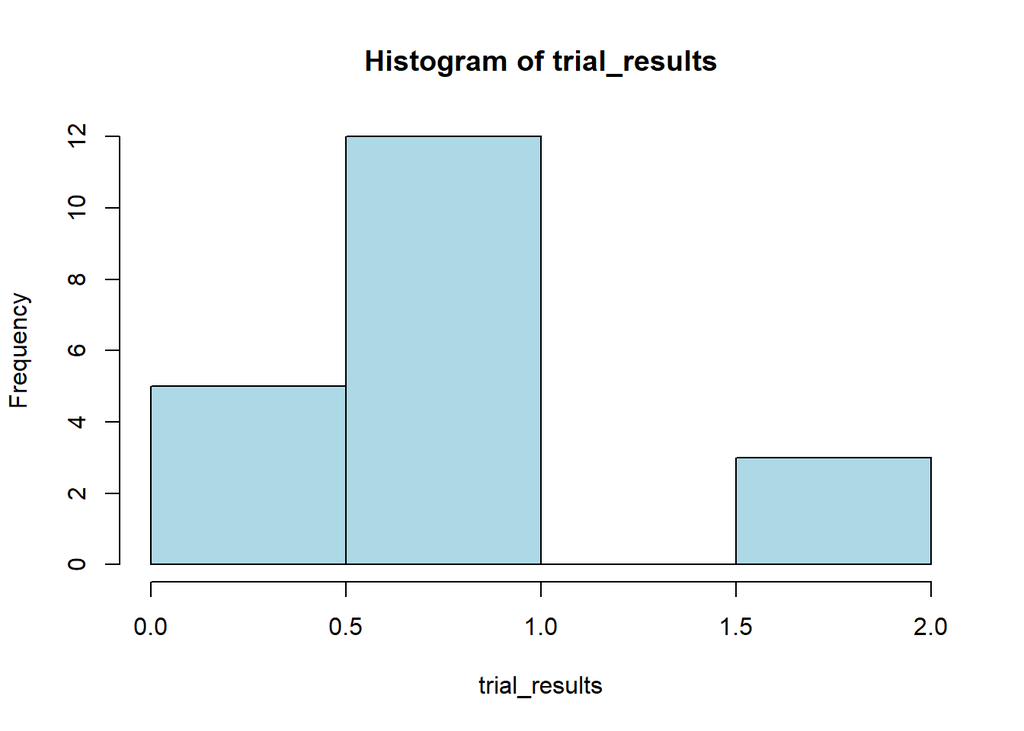

```r
hist(trial_results, breaks=3, col="lightblue")
```

## What type of distribution is this? Do you know how it is called?

Since the number of possible outcomes is limited to 3 different outcomes for this lab: * Outcomes 1: 0 heads * Outcomes 2: 1 head * Outcomes 3: 2 heads Since it can only be one of these three outcomes, it is a discrete distribution. I’m not entirely sure what “Do you know how it is called?” is referring to but if it’s asking for what kind of distribution it is, I would say it’s a **binomial** distribution. I would’ve said it was a Bernoulli’s but since there are 3 variables (0, 1, or 2 heads), it cannot be.

## Does it look symmetric, or right/left skewed?

Minding the gap in the histogram, it looks symmetrical. With the largest amount centered with 1 head.